# Project Capstone

Alberto Rossi

21/06/2020

# Data Science Specialization - SwiftKey Capstone

# Overview

The goal of this capstone is to mimic the experience of being a data scientist, exploring an area called Natural Language Processing - NLP. The idea is to apply the acquired knowledge and build a solution that, given a word initially typed, can return some terms and words that can be used / completed, in order to try to predict which word will be typed.

# Pre requirements

In order to be able to work with data and analysis, two extremely useful packages for NLP will be used: - TM - For NLP - RWeka - For Tokenization

```r
  library(tm)
  library(RWeka)
  library(tidyverse)
  library(stylo)
  library(tokenizers)
  library(stringr)

  set.seed(1906)
```

# Data loading

The reference database used to learn about words and their uses was provided by SwiftKey, a company specialized in the subject. Database URL: https://d396qusza40orc.cloudfront.net/dsscapstone/dataset/Coursera-SwiftKey.zip

```r
  # The zip file contains 4 folders, separared by language.
  # The instructions are to work only with English database.
  dirsource <- "C:/RStudio/datasciencecoursera/Scripts/ProjectCapstone/final/en_US/"
  fileslist <- list.files(path=dirsource)
  #  wordslist <- lapply(paste(dirsource, fileslist, sep="/"), function(f) {
  #  fsize <- file.info(f)[1]/1024/1024
  #  con <- file(f, open="r")
  #  lines <- readLines(con)
  #  nchars <- lapply(lines, nchar)
  #  maxchars <- which.max(nchars)
  #  nwords <- sum(sapply(strsplit(lines, "\\s+"), length))
  #  close(con)
  #  return(c(f, format(round(fsize, 2), nsmall=2), length(lines), maxchars, nwords))
  #})
  # save(filesummary, file="./Scripts/ProjectCapstone/filesummary.RData")
  #filesummary <- data.frame(matrix(unlist(wordslist), nrow=length(wordslist), byrow=T))
  load(file = "C:/RStudio/datasciencecoursera/Scripts/ProjectCapstone/filesummary.RData")
  colnames(filesummary) <- c("File", "Size(MB)", "Number lines", "Longest line", "Number Words")
  filesummary
```

```
##                                                       File Size(MB)
## 1   ./Scripts/ProjectCapstone/final/en_US//en_US.blogs.txt   200.42
## 2    ./Scripts/ProjectCapstone/final/en_US//en_US.news.txt   196.28
## 3 ./Scripts/ProjectCapstone/final/en_US//en_US.twitter.txt   159.36
##   Number lines Longest line Number Words
## 1       899288       483415     37334441
## 2        77259        14556      2643972
## 3      2360148      1484357     30373792
```

# Pre-processing and Sampling

Tokenization - identifying appropriate tokens such as words, punctuation, and numbers. Writing a function that takes a file as input and returns a tokenized version of it.

```r
  tokenForFile <- function(filepath) {
    conn <- file(filepath, "rb")
    document <- readLines(conn, encoding = "UTF-8")
    strsplit(x = document, split = "\\s+")
    close(conn)
  }
```

You might want to create a separate sub-sample dataset by reading in a random subset of the original data and writing it out to a separate file. That way, you can store the sample and not have to recreate it every time. You can use the rbinom function to “flip a biased coin” to determine whether you sample a line of text or not.

Lets sample 2% of each file, and group than in a single object.

```r
  # First file
  file_data1 <- file(paste(dirsource, fileslist, sep="/")[1], open="r")
  file_lines1 <- readLines(file_data1)
  close(file_data1)

  # Second file
  file_data2 <- file(paste(dirsource, fileslist, sep="/")[2], open="r")
  file_lines2 <- readLines(file_data2)
  close(file_data2)

  # Third file
  file_data3 <- file(paste(dirsource, fileslist, sep="/")[3], open="r")
  file_lines3 <- readLines(file_data3)
  close(file_data3)

  file_sample1 = sample(file_lines1, length(file_lines1)/50)
  file_sample2 = sample(file_lines2, length(file_lines2)/50)
  file_sample3 = sample(file_lines3, length(file_lines3)/50)

  sample <- c(file_sample1, file_sample2, file_sample3)

  rm(file_lines1, file_sample1,
     file_lines2, file_sample2,
     file_lines3, file_sample3)
```

# Data cleaning

Basic remove symbols, punctuation, whitespace and blacklisted words (profanity) from our sample data.

```r
  # Prepare Corpus
  sample <- VCorpus(VectorSource(sample))

  # Remove punctuation
  sample = tm_map(sample,removePunctuation)

  # Remove numbers from the data
  sample = tm_map(sample,removeNumbers)

  # Remove whitespace
  sample = tm_map(sample,stripWhitespace)

  # Remove black listed word (Profanity cleaning)
  conn <- file("C:/RStudio/datasciencecoursera/Scripts/ProjectCapstone/blacklist.txt", "rb")
  profanity <- readLines(conn, encoding = "UTF-8")
  close(conn)
  sample <- tm_map(sample, removeWords, profanity)
  rm(profanity)


  sampledf <- data.frame(rawtext = sapply(sample, as.character), stringsAsFactors=FALSE)
  sampledf$textLines <- iconv(sampledf$rawtext, 'UTF-8', 'ASCII')
  sampledf$textLines <- tolower(sampledf$textLines)
  sampledf <- sampledf[!is.na(sampledf$textLines),]
```

# Data exploration

Exploratory analysis - perform a thorough exploratory analysis of the data, understanding the distribution of words and relationship betwee the words in the corpora.

Understand frequencies of words and word pairs - build figures and tables to understand variation in the frequencies of words and word pairs in the data.

Tokenization process: breaking the cleaned sample into works to better work with than.

Lets break in 4 groups: one-part-words, two-part-words, three-part-words and four-part-words.

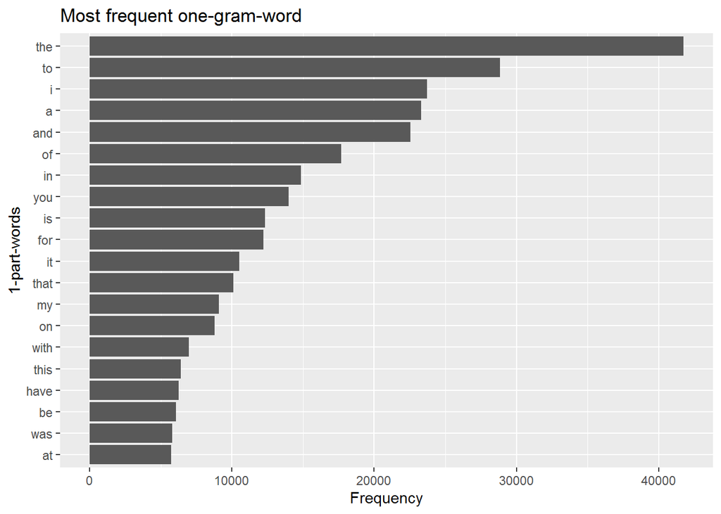

```r
  # Frequency: 1-part-word
  # Save part-word object in disk for cache -> better performance

  grams1 <- tokenize_ngrams(sampledf$textLines,n=1,n_min = 1)
  #save(grams1, file="./Scripts/ProjectCapstone/grams1.RData")
  #load(file = "./Scripts/ProjectCapstone/grams1.RData")

  grams1df <- data.frame(table(unlist(grams1)))
  grams1df <- grams1df[order(grams1df$Freq,decreasing = TRUE),]
  grams1plot <- grams1df[1:20,]

  names(grams1plot) <- c("Grams","Freq")
  ggplot(grams1plot, aes(x=reorder(Grams, Freq), y=Freq)) +
    geom_bar(stat = "identity") +  coord_flip() +
    xlab("1-part-words") + ylab("Frequency") +
    labs(title = "Most frequent one-gram-word")
```

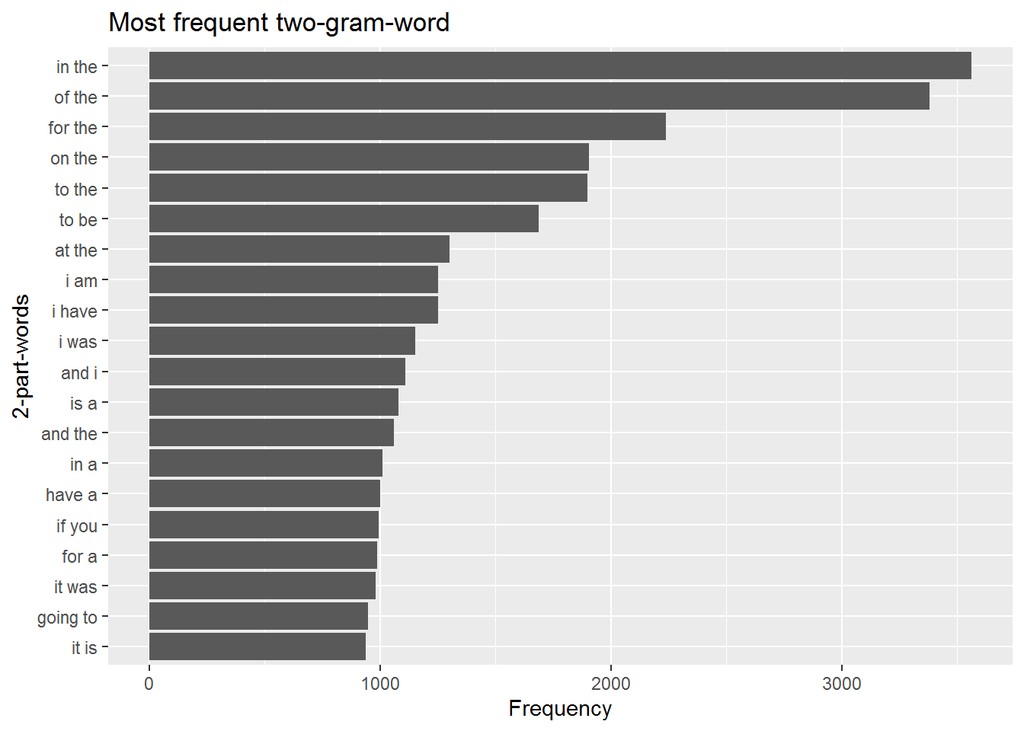

```r
  # Frequency: 2-part-word
  # Save part-word object in disk for cache -> better performance
  grams2 <- tokenize_ngrams(sampledf$textLines,n=2,n_min = 2)

  #save(grams2, file="./Scripts/ProjectCapstone/grams2.RData")
  #load(file = "./Scripts/ProjectCapstone/grams2.RData")

  grams2df <- data.frame(table(unlist(grams2)))
  grams2df <- grams2df[order(grams2df$Freq,decreasing = TRUE),]
  grams2dfplot <- grams2df[1:20,]

  names(grams2dfplot) <- c("Grams","Freq")
  ggplot(grams2dfplot, aes(x=reorder(Grams, Freq), y=Freq)) +
    geom_bar(stat = "identity") +  coord_flip() +
    xlab("2-part-words") + ylab("Frequency") +
    labs(title = "Most frequent two-gram-word")
```

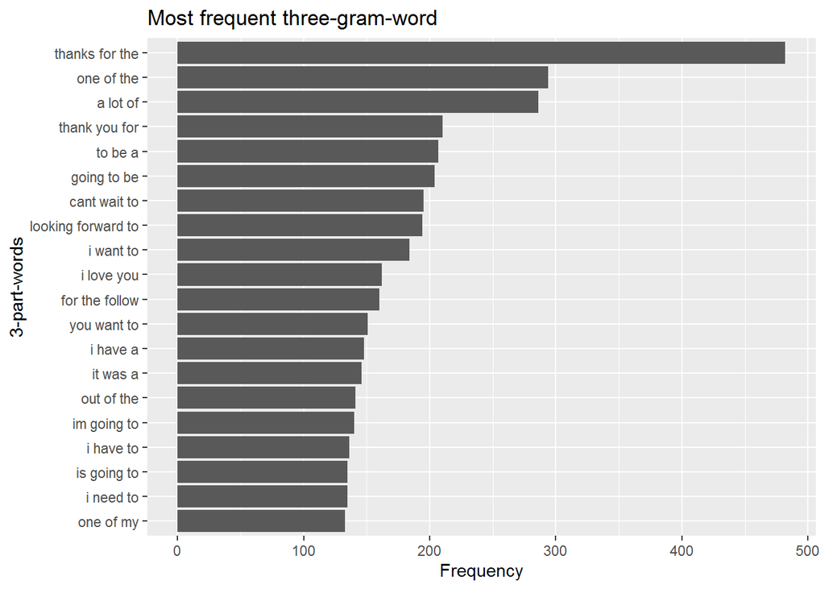

```r
  # Frequency: 3-part-word
  # Save part-word object in disk for cache -> better performance

  grams3 <- tokenize_ngrams(sampledf$textLines,n=3,n_min = 3)
  #save(grams3, file="./Scripts/ProjectCapstone/grams3.RData")
  #load(file = "./Scripts/ProjectCapstone/grams3.RData")

  grams3df <- data.frame(table(unlist(grams3)))
  grams3df <- grams3df[order(grams3df$Freq,decreasing = TRUE),]
  grams3dfplot <- grams3df[1:20,]
  names(grams3dfplot) <- c("Grams","Freq")
  ggplot(grams3dfplot, aes(x=reorder(Grams, Freq), y=Freq)) +
    geom_bar(stat = "identity") +  coord_flip() +
    xlab("3-part-words") + ylab("Frequency") +
    labs(title = "Most frequent three-gram-word")
```

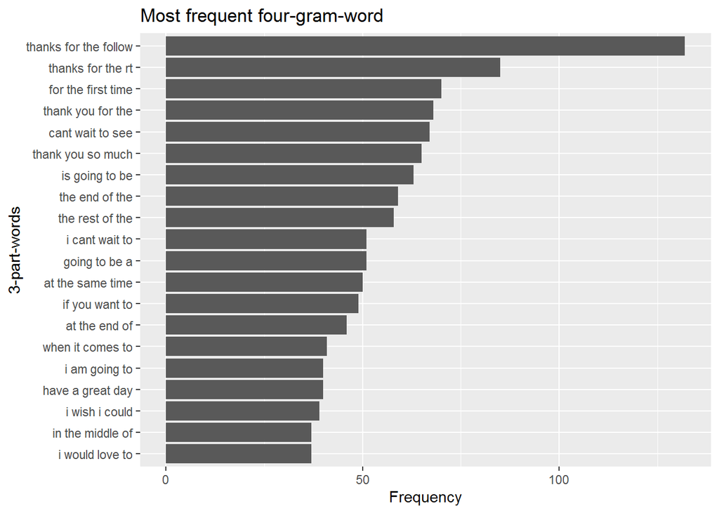

```r
  # Frequency: 4-part-word
  # Save part-word object in disk for cache -> better performance

  grams4 <- tokenize_ngrams(sampledf$textLines,n=4,n_min = 4)
  #save(grams4, file="./Scripts/ProjectCapstone/grams4.RData")
  #load(file = "./Scripts/ProjectCapstone/grams4.RData")

  grams4df <- data.frame(table(unlist(grams4)))
  grams4df <- grams4df[order(grams4df$Freq,decreasing = TRUE),]
  grams4dfplot <- grams4df[1:20,]
  names(grams4dfplot) <- c("Grams","Freq")
  ggplot(grams4dfplot, aes(x=reorder(Grams, Freq), y=Freq)) +
    geom_bar(stat = "identity") +  coord_flip() +
    xlab("3-part-words") + ylab("Frequency") +
    labs(title = "Most frequent four-gram-word")
```

How many unique words do you need in a frequency sorted dictionary to cover 50% of all word instances in the language? 90%?

```r
  # Data = NGram Tokenizer
  # Percentage Cover: words ratio to cover in data
   wordCoverage <- function(data, percentageCover){
    pcover <- percentageCover*sum(data$Freq)
    nwords <- 0
    for (i in 1:nrow(data)) {
      if (nwords >= pcover) {
        return (i)
      }
      nwords <- nwords+data$Freq[i]
    }
  }
  print("How many word to cover 50% of data - one-part-words:")
```

```
## [1] "How many word to cover 50% of data - one-part-words:"
```

```r
  wordCoverage(grams1df, 0.5)
```

```
## [1] 122
```

```r
  print("How many word to cover 90% of data - two-word-words:")
```

```
## [1] "How many word to cover 90% of data - two-word-words:"
```

```r
  wordCoverage(grams1df, 0.9)
```

```
## [1] 6384
```

# Building predicting model

The prediction model will use the preprocessed 2, 3 and 4 gram models to search for the typed words and return the most frequent ones for the suggested completion.

They will be created in function format for easier use in the future application.

```r
  grams2df <- separate(grams2df, 1, c("word1", "word2"), sep=" ")
  grams3df <- separate(grams3df, 1, c("word1", "word2", "word3"), sep=" ")
  grams4df <- separate(grams4df, 1, c("word1", "word2", "word3", "word4"), sep=" ")
```

The following functions will process the base word to try to predict and suggest the next word, based on the sample of worked and clean data.

```r
  # Extract words from sentence inputed and clean for punctuation and numbers
  extractWordCleaned <- function(words){
    textInput <- tolower(words)
    textInput <- removePunctuation(textInput)
    textInput <- removeNumbers(textInput)
    textInput <- str_replace_all(textInput, "[^[:alnum:]]", " ")
    textInput <- stripWhitespace(textInput)
    textInput <- txt.to.words.ext(textInput, corpus.lang="English.all", preserve.case = TRUE)
    return(textInput)
  }

  #Predict next word base on a baseword(s)
  predictNextWord <- function(baseword)
  {
    #Extract and clean input data
    words <- extractWordCleaned(baseword)
    wordsC <- length(wordInput)

    nextWord <- c()

    # Check if input is valid
    if(wordsC == 0) {
      prediction <- "No word entered."
      return (nextWord)
    }

    # Try to predict the next word in a sentence of more than four words
    if(wordsC > 3) {
      wordInput <- words[(wordsC-2):wordsC]
      nextWord <- predict4Gram(words[1],words[2],words[3])
    } else if(wordsC == 3) {  # Try to predict the next word in a sentence of three words
      nextWord <- predict4Gram(words[1],words[2],words[3])
    } else if(wordsC == 2) { # Try to predict the next word in a sentence of two words
      nextWord <- predict3Gram(words[1],words[2])
    } else if(wordsC == 1) { # Try to predict the next word in a sentence of one word
      prediction <- predict2Gram(words[1])
    }

    # Test if prediction worked
    if(length(prediction)==0) {
      prediction <- "Next word not know from out database."
    }
    return (prediction[1:3])
  }

   # Try to search the 2gram base for the last input word.
  predict2Gram <- function(words1) {
    predictWord <- filter(grams2df,(word1 == words1))$word2
    return (predictWord)
  }

  # Try to search the 3gram base for the last two input words, or, if not, try to search the last entries in 3gram and 2gram bases.
  predict3Gram <- function(words1,words2) {
    predictWord <- filter(grams3df,(word1 == words1 & word2 == inputWord2))$word3
    if(length(predictWord)==0) {
      predictWord <- filter(grams3df,(word2 == words2))$word3
      if(length(predictWord)== 0) {
        predictWord <- filter(grams3df,(word1 == words2))$word2
        if(length(predictWord) ==0 ) {
          predictWord <- matchTwoGram(words2)
        }
      }
    }
    return (predictWord)
  }

    # Try to search the 4gram base for the last three input words, or, if not, try to search the last two entries in 4gram and 3gram bases.
  predict4Gram <- function (words1,words2,words3) {
    predictWord <- filter(grams4df,(word1 == words1
                                    & word2 == words2
                                    & word3 == words3))$word4
    if(length(predictWord) == 0) {
      predictWord <- filter(grams4df,(word2 == words2 & word3 == words3))$word4
      if(length(predictWord) == 0) {
        predictWord <- filter(grams4df,(word1 == words2 & word2 == words3))$word3
        if(length(predictWord) ==0) {
          predictWord <- matchThreeGram(words2,words3)
        }
      }
    }
    return (predictWord)
  }
```